# Network inference with FlashWeave

```r
# res_healthy_top <- run_flashweave_bootstrap(healthy_df_top, n_bootstrap = 100, subsample_pcts = c(0.6, 0.7, 0.8), max_attempts = 120, prevalence_threshold = 0)
# res_diseased_top <- run_flashweave_bootstrap(diseased_df_top, n_bootstrap = 100, subsample_pcts = c(0.6, 0.7, 0.8), max_attempts = 120, prevalence_threshold = 0)
#
# saveRDS(res_healthy_top, file = str_c(result_dir(), "/flashweave_res_healthy_CDI_top_20260324.rds"))
# saveRDS(res_diseased_top, file = str_c(result_dir(), "/flashweave_res_diseased_CDI_top_20260324.rds"))
```

```r
res_healthy_top <- readRDS(file = str_c(result_dir(), "/flashweave_res_healthy_CDI_top_20260324.rds"))
res_diseased_top <- readRDS(file = str_c(result_dir(), "/flashweave_res_diseased_CDI_top_20260324.rds"))

df_res_healthy_top <- get_flashweave_results(res_healthy_top)
df_res_diseased_top <- get_flashweave_results(res_diseased_top)

df_res_top <-
  bind_rows(
    df_res_healthy_top |> mutate(group = "Healthy"),
    df_res_diseased_top |> mutate(group = "Diseased")
  )
```

We plot the results below.

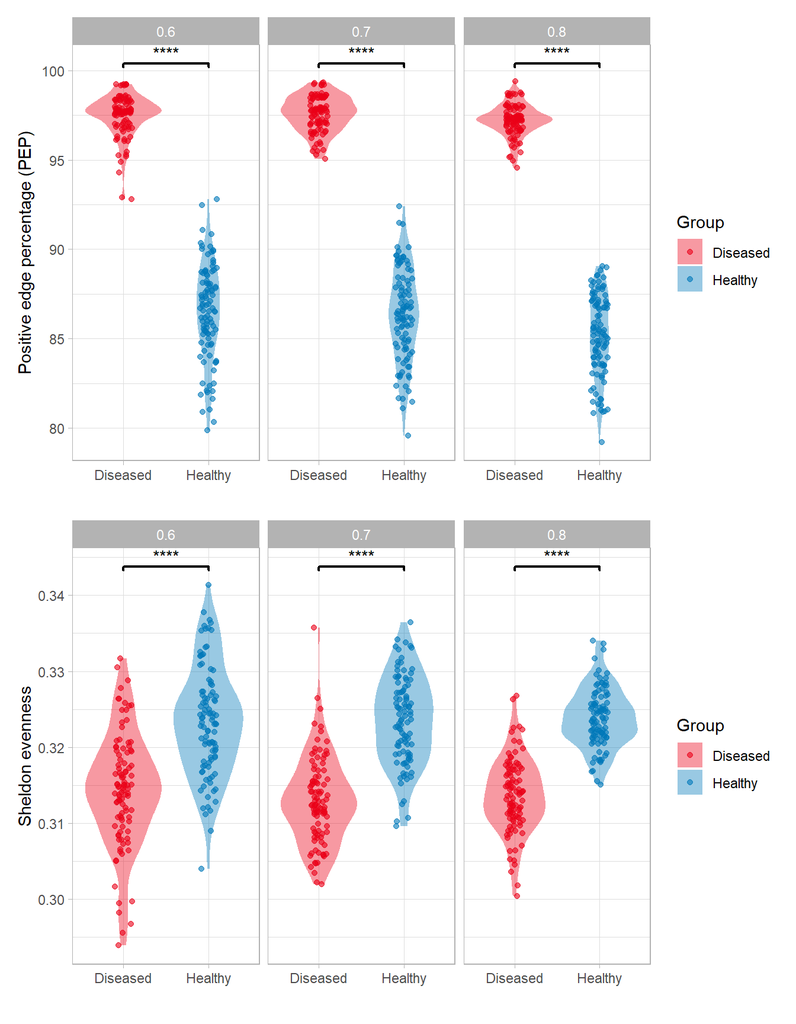

```r
# PEP plot

df_res_top |>
  ggplot() +
  aes(x = group, y = pep, color = group, fill = group) +
  geom_violin(alpha = 0.4, color = NA) +
  geom_point(position = position_jitter(width = 0.1), alpha = 0.6) +
  scale_color_manual(values = c("Healthy" = "#0078B9", "Diseased" = "#EA0017")) +
  scale_fill_manual(values  = c("Healthy" = "#0078B9", "Diseased" = "#EA0017")) +
  facet_wrap(~ fraction) +
  labs(x = "", y = "Positive edge percentage (PEP)", color = "Group", fill = "Group") +
  stat_compare_means(
    comparisons = list(c("Healthy", "Diseased")),
    method = "wilcox.test",
    label = "p.signif",
    tip.length = 0.01,
    bracket.size = 0.8,
    fontface = "bold"
  ) +

df_res_top |>
  ggplot() +
  aes(x = group, y = sheldon, color = group, fill = group) +
  geom_violin(alpha = 0.4, color = NA) +
  geom_point(position = position_jitter(width = 0.1), alpha = 0.6) +
  scale_color_manual(values = c("Healthy" = "#0078B9", "Diseased" = "#EA0017")) +
  scale_fill_manual(values  = c("Healthy" = "#0078B9", "Diseased" = "#EA0017")) +
  facet_wrap(~ fraction) +
  labs(x = "", y = "Sheldon evenness", color = "Group", fill = "Group") +
  stat_compare_means(
    comparisons = list(c("Healthy", "Diseased")),
    method = "wilcox.test",
    label = "p.signif",
    tip.length = 0.01,
    bracket.size = 0.8,
    fontface = "bold"
  ) +

  patchwork::plot_layout(nrow = 2)
```

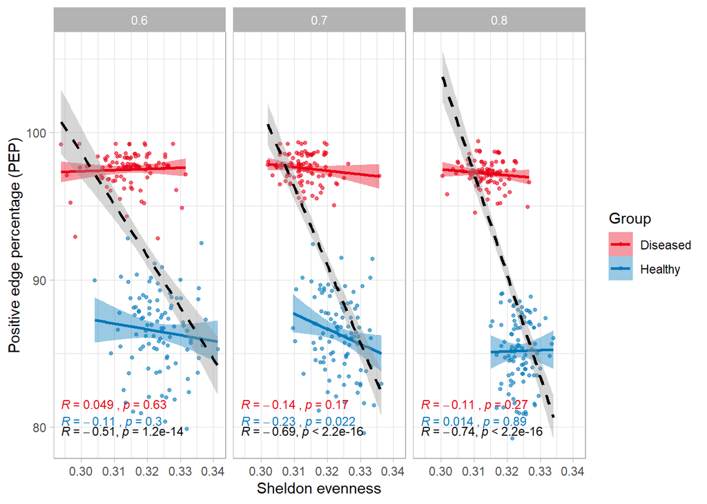

```r
df_res_top |>
  ggplot() +
  aes(x = sheldon, y = pep, color = group, fill = group) +
  geom_point(alpha = 0.6, size = 1) +
  geom_smooth(method = "lm", se = TRUE) +
  geom_smooth(aes(x = sheldon, y = pep), method = "lm",
              se = TRUE, inherit.aes = FALSE,
              color = "black", linetype = "dashed") +
  ggpubr::stat_cor(aes(label = after_stat(paste(r.label, p.label, sep = "~`,`~"))),
                   method = "pearson", label.x.npc = "left", label.y.npc = 0.12,
                   size = 3, show.legend = FALSE) +
  ggpubr::stat_cor(aes(x = sheldon, y = pep), method = "pearson",
                   inherit.aes = FALSE, color = "black",
                   label.x.npc = "left", label.y.npc = 0.03,
                   size = 3) +
  scale_color_manual(values = c("Healthy" = "#0078B9", "Diseased" = "#EA0017")) +
  scale_fill_manual(values  = c("Healthy" = "#0078B9", "Diseased" = "#EA0017")) +
  facet_wrap(~ fraction) +
  labs(x = "Sheldon evenness", y = "Positive edge percentage (PEP)", color = "Group", fill = "Group")
```

## 2.4 CRC cohort

```r
tmp <-
  mae[["CRC"]] |>
  assay() |>
  t() |>
  as.data.frame() |>
  rownames_to_column("uid") |>
  pivot_longer(-uid, names_to = "taxon", values_to = "count") |>
  group_by(uid) |>
  mutate(rel_ab = count/sum(count)) |>
  left_join(
    mae[["CRC"]] |> colData() |> as_tibble(rownames = "uid") |> select(uid, cohort),
    by = join_by(uid)
  )
```

```r
tmp_healthy <- tmp |> filter(cohort == "H")
tmp_diseased <- tmp |> filter(cohort == "CRC")

# for healthy samples

healthy_df <-
  tmp_healthy |>
  select(uid, taxon, rel_ab) |>
  pivot_wider(names_from = taxon, values_from = rel_ab) |>
  column_to_rownames("uid") |>
  t()

# for diseased samples

diseased_df <-
  tmp_diseased |>
  select(uid, taxon, rel_ab) |>
  pivot_wider(names_from = taxon, values_from = rel_ab) |>
  column_to_rownames("uid") |>
  t()
```

We run the FlashWeave network inference for healthy and diseased samples separately, with the following parameters: `n_bootstrap = 100`, `subsample_pcts = c(0.6, 0.7, 0.8)`, and `max_attempts = 120`. This is done in the chunk code below.

```r
# res_healthy <- run_flashweave_bootstrap(healthy_df, n_bootstrap = 100, subsample_pcts = c(0.6, 0.7, 0.8), max_attempts = 120, prevalence_threshold = 0.05)
# res_diseased <- run_flashweave_bootstrap(diseased_df, n_bootstrap = 100, subsample_pcts = c(0.6, 0.7, 0.8), max_attempts = 120, prevalence_threshold = 0.05)
#
# saveRDS(res_healthy, file = str_c(result_dir(), "/flashweave_res_healthy_CRC_20260324.rds"))
# saveRDS(res_diseased, file = str_c(result_dir(), "/flashweave_res_diseased_CRC_20260324.rds"))
```

We load the results in the chunk code below.

```r
res_healthy <- readRDS(file = str_c(result_dir(), "/flashweave_res_healthy_CRC_20260324.rds"))
res_diseased <- readRDS(file = str_c(result_dir(), "/flashweave_res_diseased_CRC_20260324.rds"))
```

```r
df_res_healthy <- get_flashweave_results(res_healthy)
df_res_diseased <- get_flashweave_results(res_diseased)

df_res <-
  bind_rows(
    df_res_healthy |> mutate(group = "Healthy"),
    df_res_diseased |> mutate(group = "Diseased")
  )
```

We plot the results below.

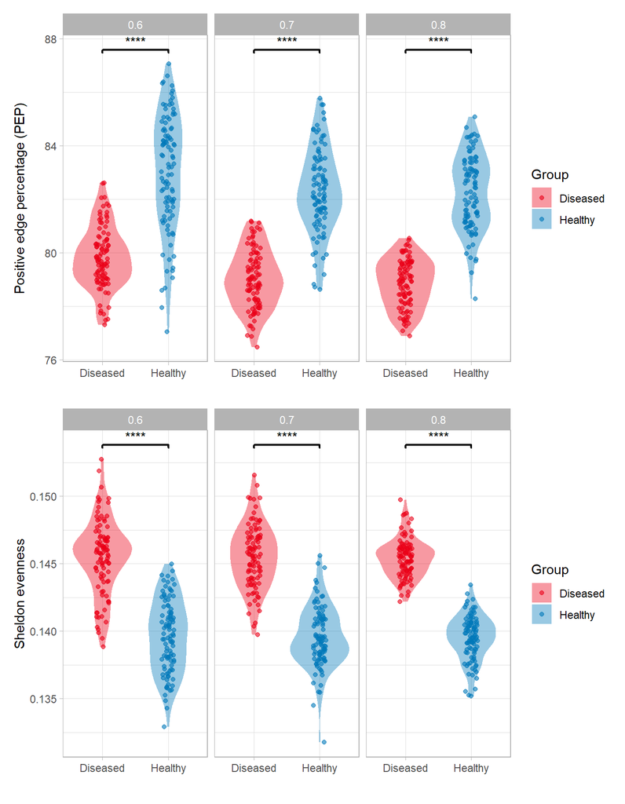

```r
df_res |>
  ggplot() +
  aes(x = group, y = pep, color = group, fill = group) +
  geom_violin(alpha = 0.4, color = NA) +
  geom_point(position = position_jitter(width = 0.1), alpha = 0.6) +
  scale_color_manual(values = c("Healthy" = "#0078B9", "Diseased" = "#EA0017")) +
  scale_fill_manual(values  = c("Healthy" = "#0078B9", "Diseased" = "#EA0017")) +
  facet_wrap(~ fraction) +
  labs(x = "", y = "Positive edge percentage (PEP)", color = "Group", fill = "Group") +
  stat_compare_means(
    comparisons = list(c("Healthy", "Diseased")),
    method = "wilcox.test",
    label = "p.signif",
    tip.length = 0.01,
    bracket.size = 0.8,
    fontface = "bold"
  ) +
df_res |>
  ggplot() +
  aes(x = group, y = sheldon, color = group, fill = group) +
  geom_violin(alpha = 0.4, color = NA) +
  geom_point(position = position_jitter(width = 0.1), alpha = 0.6) +
  scale_color_manual(values = c("Healthy" = "#0078B9", "Diseased" = "#EA0017")) +
  scale_fill_manual(values  = c("Healthy" = "#0078B9", "Diseased" = "#EA0017")) +
  facet_wrap(~ fraction) +
  labs(x = "", y = "Sheldon evenness", color = "Group", fill = "Group") +
  stat_compare_means(
    comparisons = list(c("Healthy", "Diseased")),
    method = "wilcox.test",
    label = "p.signif",
    tip.length = 0.01,
    bracket.size = 0.8,
    fontface = "bold"
  ) +

  patchwork::plot_layout(nrow = 2)
```

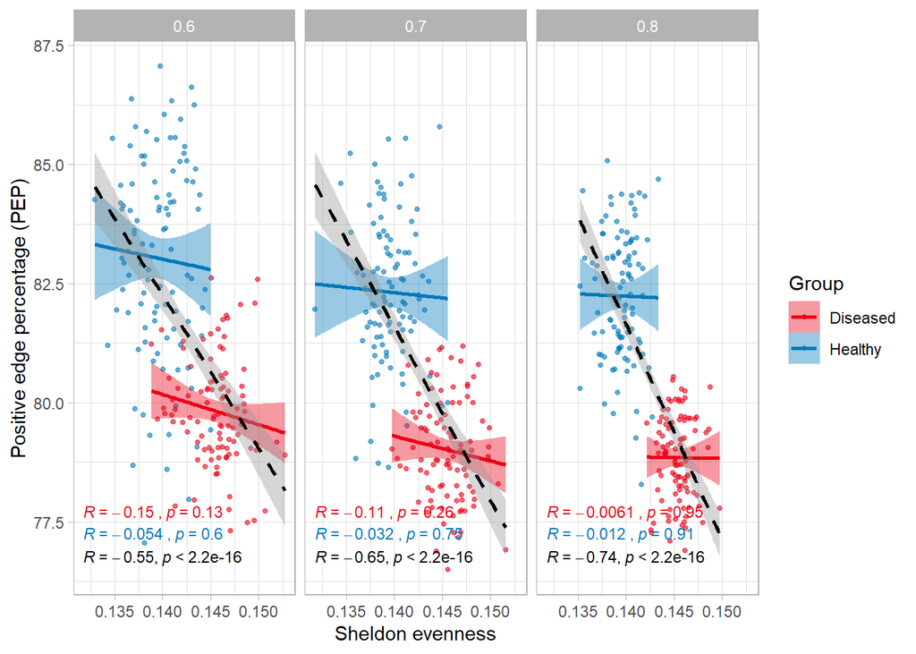

```r
df_res |>
  ggplot() +
  aes(x = sheldon, y = pep, color = group, fill = group) +
  geom_point(alpha = 0.6, size = 1) +
  geom_smooth(method = "lm", se = TRUE) +
  geom_smooth(aes(x = sheldon, y = pep), method = "lm",
              se = TRUE, inherit.aes = FALSE,
              color = "black", linetype = "dashed") +
  ggpubr::stat_cor(aes(label = after_stat(paste(r.label, p.label, sep = "~`,`~"))),
                   method = "pearson", label.x.npc = "left", label.y.npc = 0.12,
                   size = 3, show.legend = FALSE) +
  ggpubr::stat_cor(aes(x = sheldon, y = pep), method = "pearson",
                   inherit.aes = FALSE, color = "black",
                   label.x.npc = "left", label.y.npc = 0.03,
                   size = 3) +
  scale_color_manual(values = c("Healthy" = "#0078B9", "Diseased" = "#EA0017")) +
  scale_fill_manual(values  = c("Healthy" = "#0078B9", "Diseased" = "#EA0017")) +
  facet_wrap(~ fraction) +
  labs(x = "Sheldon evenness", y = "Positive edge percentage (PEP)", color = "Group", fill = "Group")
```

We will now perform the network analysis on top taxa selected based on their relative abundance. We select a data-driven threshold for relative abundance, which is shown in the plot below. We will keep taxa with a mean relative abundance of at least 0.001 (that is, log10 mean relative abundance of -3). This threshold was chosen since we need a number of “core” taxa smaller than the number of remaining taxa after prevalence filtering. Taxa with a mean relative abundance below this threshold will be grouped in a category named “Other”. This is done in the chunk code below.

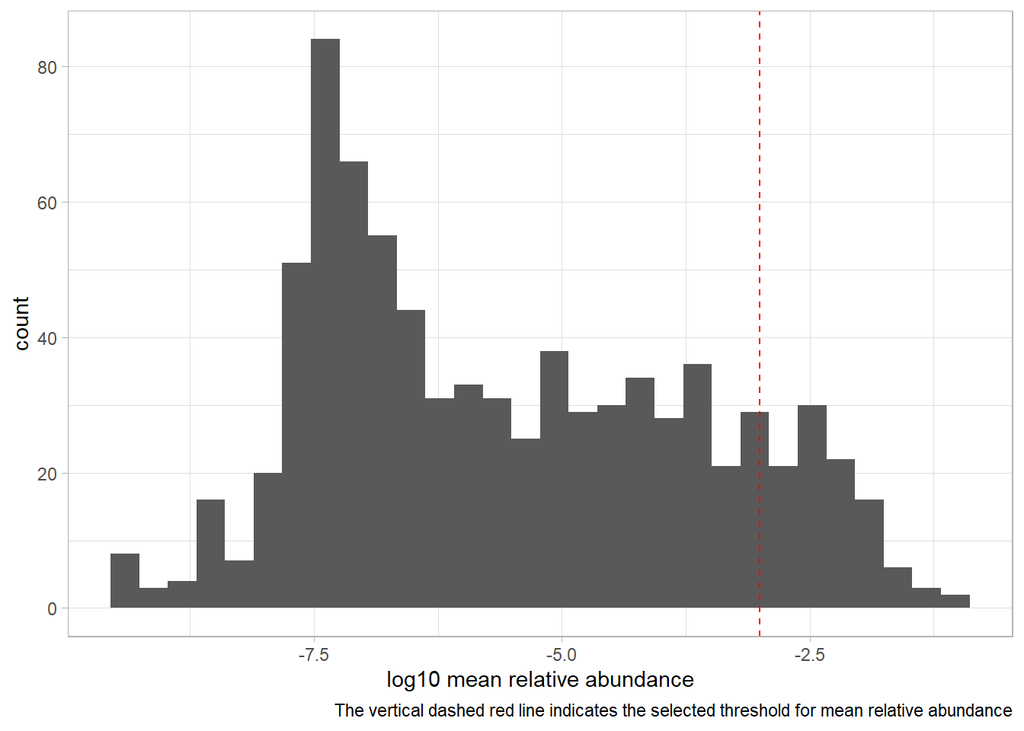

```r
tmp |>
  group_by(taxon) |>
  summarise(mean_rel_ab = mean(rel_ab)) |>
  arrange(desc(mean_rel_ab)) |>
  ggplot() +
  aes(x = mean_rel_ab |> log10()) +
  geom_histogram(bins = 30) +
  geom_vline(xintercept = -3, linetype = "dashed", color = "red") +
  labs(x = "log10 mean relative abundance", y = "count",
       caption = "The vertical dashed red line indicates the selected threshold for mean relative abundance")
```

```r
tmp_filtered_healthy_top <-
  filter_abundance(tmp_healthy, abundance_threshold = 10^-3) |>
  left_join(
    mae[["CRC"]] |> colData() |> as_tibble(rownames = "uid") |> select(uid, cohort),
    by = join_by(uid)
  )
```

```
Keeping 105 out of 837 taxa with mean abundance >= 0.001
```

```r
tmp_filtered_diseased_top <-
  filter_abundance(tmp_diseased, abundance_threshold = 10^-3) |>
  left_join(
    mae[["CRC"]] |> colData() |> as_tibble(rownames = "uid") |> select(uid, cohort),
    by = join_by(uid)
  )
```

```
Keeping 106 out of 837 taxa with mean abundance >= 0.001
```

```r
healthy_df_top <-
  tmp_filtered_healthy_top |>
  select(uid, taxon, rel_ab) |>
  pivot_wider(names_from = taxon, values_from = rel_ab) |>
  column_to_rownames("uid") |>
  t()

diseased_df_top <-
  tmp_filtered_diseased_top |>
  select(uid, taxon, rel_ab) |>
  pivot_wider(names_from = taxon, values_from = rel_ab) |>
  column_to_rownames("uid") |>
  t()
```

```r
# res_healthy_top <- run_flashweave_bootstrap(healthy_df_top, n_bootstrap = 100, subsample_pcts = c(0.6, 0.7, 0.8), max_attempts = 120, prevalence_threshold = 0)
# res_diseased_top <- run_flashweave_bootstrap(diseased_df_top, n_bootstrap = 100, subsample_pcts = c(0.6, 0.7, 0.8), max_attempts = 120, prevalence_threshold = 0)
#
# saveRDS(res_healthy_top, file = str_c(result_dir(), "/flashweave_res_healthy_CRC_top_20260324.rds"))
# saveRDS(res_diseased_top, file = str_c(result_dir(), "/flashweave_res_diseased_CRC_top_20260324.rds"))
```

```r
res_healthy_top <- readRDS(file = str_c(result_dir(), "/flashweave_res_healthy_CRC_top_20260324.rds"))
res_diseased_top <- readRDS(file = str_c(result_dir(), "/flashweave_res_diseased_CRC_top_20260324.rds"))
```

```r
df_res_healthy_top <- get_flashweave_results(res_healthy_top)
df_res_diseased_top <- get_flashweave_results(res_diseased_top)

df_res_top <-
  bind_rows(
    df_res_healthy_top |> mutate(group = "Healthy"),
    df_res_diseased_top |> mutate(group = "Diseased")
  )
```

We plot the results below.

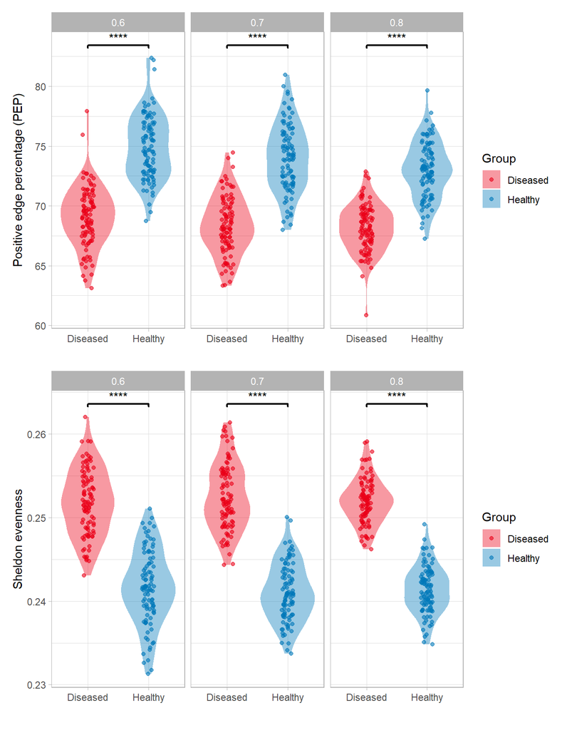

```r
df_res_top |>
  ggplot() +
  aes(x = group, y = pep, color = group, fill = group) +
  geom_violin(alpha = 0.4, color = NA) +
  geom_point(position = position_jitter(width = 0.1), alpha = 0.6) +
  scale_color_manual(values = c("Healthy" = "#0078B9", "Diseased" = "#EA0017")) +
  scale_fill_manual(values  = c("Healthy" = "#0078B9", "Diseased" = "#EA0017")) +
  facet_wrap(~ fraction) +
  labs(x = "", y = "Positive edge percentage (PEP)", color = "Group", fill = "Group") +
  stat_compare_means(
    comparisons = list(c("Healthy", "Diseased")),
    method = "wilcox.test",
    label = "p.signif",
    tip.length = 0.01,
    bracket.size = 0.8,
    fontface = "bold"
  ) +

df_res_top |>
  ggplot() +
  aes(x = group, y = sheldon, color = group, fill = group) +
  geom_violin(alpha = 0.4, color = NA) +
  geom_point(position = position_jitter(width = 0.1), alpha = 0.6) +
  scale_color_manual(values = c("Healthy" = "#0078B9", "Diseased" = "#EA0017")) +
  scale_fill_manual(values  = c("Healthy" = "#0078B9", "Diseased" = "#EA0017")) +
  facet_wrap(~ fraction) +
  labs(x = "", y = "Sheldon evenness", color = "Group", fill = "Group") +
  stat_compare_means(
    comparisons = list(c("Healthy", "Diseased")),
    method = "wilcox.test",
    label = "p.signif",
    tip.length = 0.01,
    bracket.size = 0.8,
    fontface = "bold"
  ) +
  patchwork::plot_layout(nrow = 2)
```

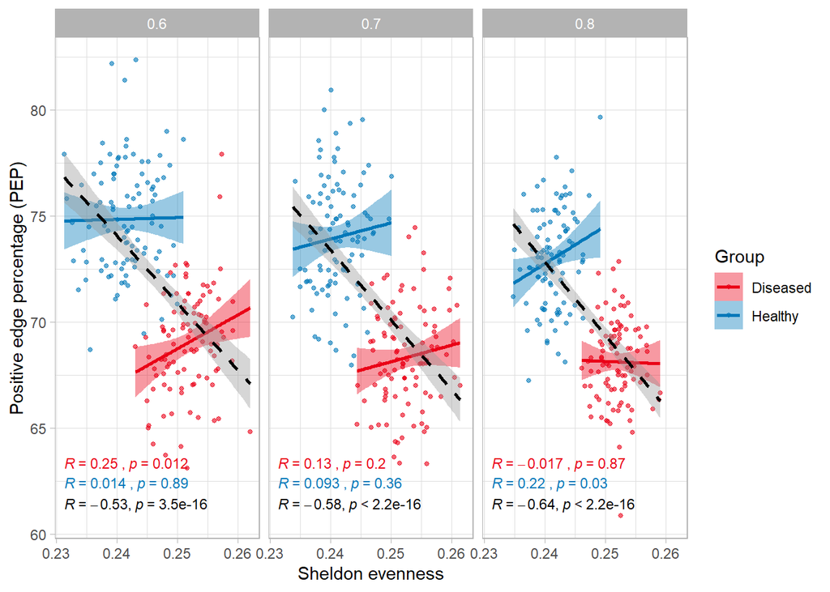

```r
df_res_top |>
  ggplot() +
  aes(x = sheldon, y = pep, color = group, fill = group) +
  geom_point(alpha = 0.6, size = 1) +
  geom_smooth(method = "lm", se = TRUE) +
  geom_smooth(aes(x = sheldon, y = pep), method = "lm",
              se = TRUE, inherit.aes = FALSE,
              color = "black", linetype = "dashed") +
  ggpubr::stat_cor(aes(label = after_stat(paste(r.label, p.label, sep = "~`,`~"))),
                   method = "pearson", label.x.npc = "left", label.y.npc = 0.12,
                   size = 3, show.legend = FALSE) +
  ggpubr::stat_cor(aes(x = sheldon, y = pep), method = "pearson",
                   inherit.aes = FALSE, color = "black",
                   label.x.npc = "left", label.y.npc = 0.03,
                   size = 3) +
  scale_color_manual(values = c("Healthy" = "#0078B9", "Diseased" = "#EA0017")) +
  scale_fill_manual(values  = c("Healthy" = "#0078B9", "Diseased" = "#EA0017")) +
  facet_wrap(~ fraction) +
  labs(x = "Sheldon evenness", y = "Positive edge percentage (PEP)", color = "Group", fill = "Group")
```